# 1st Laboratory

Mikel Barrenetxea

2022-09-22

# Introduction to R and RStudio

First time users often confuse the R and RStudio. At its simplest, R is like a car’s engine while RStudio is like a car’s dashboard.

[figure not shown]

More precisely, R is a programming language that runs computations, while RStudio is an *integrated development environment (IDE)* that provides an interface by adding many convenient features and tools. So just as the way of having access to a speedometer, rearview mirrors, and a navigation system makes driving much easier, using RStudio’s interface makes using R much easier as well.

## Installing R and RStudio

You will first need to download and install both R and RStudio (Desktop version) on your computer. It is important that you install R first and then install RStudio.

1. **You must do this first:** Download and install R by going to https://cloud.r-project.org/.
2. **You must do this second:** Download and install RStudio at https://www.rstudio.com/products/rstudio/download/.

## Using R via RStudio

Recall our car analogy from earlier. Much as we don’t drive a car by interacting directly with the engine but rather by interacting with elements on the car’s dashboard, we won’t be using R directly but rather we will use RStudio’s interface. After you install R and RStudio on your computer, you’ll have two new *programs* (also called *applications*) you can open. We’ll always work in RStudio and not in the R application.

[figure not shown]

After you open RStudio, you should see something similar to this:

[figure not shown]

Note the three *panes* which are three panels dividing the screen: the *console pane*, the *files pane*, and the *environment pane*.

# RMarkdown

This file you are working on is written in Rmarkdown(.Rmd) format because I want to write not only R commands but add some extra explanations to them. What’s more, I can write math equations too using [$\LaTeX$ syntax](https://wch.github.io/latexsheet/latexsheet-a4.pdf). For example,

$$F(x) = \int_a^x f(t)\, dt$$

R Markdown is a format for writing reproducible, dynamic reports with R. Use it to embed R code and results into slideshows, PDFs, html documents, Word files and more.

You can find how to work with R markdown in RStudio in the following file: [R Markdown Cheat Sheet](https://raw.githubusercontent.com/rstudio/cheatsheets/main/rmarkdown-2.0.pdf).

Look in that file for the answers of some questions about the .Rmd file you are working on:

> **QUESTION: When you compile this file, which is the format of the output file by default?**

> **ANSWER:**

> **QUESTION: What do you need to do in order to include and execute R code in this file?**

> **ANSWER:**

> **QUESTION: If you only want to show the results not the code which parameter do you use in the corresponding chunk of code?**

> **ANSWER:**

> **QUESTION: Which is the extension of this file?**

> **ANSWER:**

# Some base R

In this section we will review some basic concepts and commands with R programming language. You can find this well summarized in this [Cheat Sheet](https://raw.githubusercontent.com/rstudio/cheatsheets/main/base-r.pdf).

## Get help

To get help we use the interrogation symbol `?` before the name of the function. Also, you can use the `help` pane located on the right bottom in RStudio or other ways.

```r
?summary
```

## Working directory

Get the current working directory with this command:

```r
getwd()
```

```
## [1] "/Users/mikelba/Downloads/lab01"
```

If you want to change the directory, use the function `setwd()` and give the path to the directory you want to set. For example, try to set the folder `lab01` as your working directory.

```r
# Text after the # symbol is a comment. Sometimes you will find commented commands you need to uncomment firs for running, like this one:
# setwd()
```

You can use the `Files` pane located at the bottom right in RStudio.

## Installing and loading packages

R packages extend the functionality of R by providing additional functions, data, and documentation. They are written by a worldwide community of R users and can be downloaded for free from the internet.

When we install R it will come with some default packages included. But there are so many other functions that have to be installed before using.

For installing any R package we can use the command `install.packages()` or the `Packages` pane at the bottom right in RStudio.

```r
# install.packages("palmerpenguins")
```

Once the package is installed in our system, for using the functions included in the package, first we have to load the package with the function `library`:

```r
library(palmerpenguins)
head(penguins)
```

```
## # A tibble: 6 × 8
##   species island    bill_length_mm bill_depth_mm flipper_l…¹ body_…² sex    year
##   <fct>   <fct>              <dbl>         <dbl>       <int>   <int> <fct> <int>
## 1 Adelie  Torgersen           39.1          18.7         181    3750 male   2007
## 2 Adelie  Torgersen           39.5          17.4         186    3800 fema…  2007
## 3 Adelie  Torgersen           40.3          18           195    3250 fema…  2007
## 4 Adelie  Torgersen           NA            NA            NA      NA <NA>   2007
## 5 Adelie  Torgersen           36.7          19.3         193    3450 fema…  2007
## 6 Adelie  Torgersen           39.3          20.6         190    3650 male   2007
## # … with abbreviated variable names ¹flipper_length_mm, ²body_mass_g
```

## Reading files

Usually, we will work with data saved in a file. There are a lot of file formats for storing in a file `csv, txt, json, xml, ...` .

```r
survey <- read.table("survey.txt", header = TRUE)
head(survey)
```

```
##   Height Genre Hours Work Smoker Commute How Sport Internet TV Year
## 1   1.83     M    40    N      N      30   X     2       80  5 2021
## 2 175.00     M    10    N      N      10   A     2      200 30 2021
## 3 159.00     M    14    N      N       5   O     2      240  0 2021
## 4 163.00     F    15    N      N       4   B     6      160 60 2021
## 5 179.00     M    11    N      N      70   A     6      180 12 2021
## 6   1.81     M    17    N      N      65   X     2      160  0 2021
```

## Basic commands

```r
result <- 5+5
```

Once you have executed the command you will see a variable called `result` in the `Environment` pane at the top right.

```r
result <- result + 4
```

Now the variable `result` has value 14.

However, when we work with R programming language we will usually work with vectors and matrices. Suppose we are the owners of a store and we annotate the sales of a week.

```r
week1 <- c(550, 475, 415, 420, 620)
week1
```

```
## [1] 550 475 415 420 620
```

```r
week2 <- c(570, 415, 401, 422, 600)
week2
```

```
## [1] 570 415 401 422 600
```

If we want to compare the two weeks:

```r
day_by_day <- week1 - week2
day_by_day
```

```
## [1] -20  60  14  -2  20
```

If we want to compare the total sales of each week:

```r
difference <- sum(week1) - sum(week2)
difference
```

```
## [1] 72
```

It seems that we have earn more money the first week. But what does the `sum()` function do? Use the `help`.

How much money have we won in the first week on average?

```r
# average1 <- sum(week1)/length(week1)
# average1
```

And in the second week? Use the `mean()` function this time:

```r
# r_average2 <- mean()
# r_average2
```

We want to check if the average we computed and the average computed by mean have the same value.

```r
# average2 <- sum(week2)/length(week2)
# r_average1 <- mean(week1)
#
# same1 <- average1 == r_average1
# same1
# same2 <- average2 == r_average2
# same2
# same12 <- average1 == r_average2
# same12
```

We can also work with matrices:

```r
a <- c(3, 6, 9, 7.8, 2.1, 4.2)
a
```

```
## [1] 3.0 6.0 9.0 7.8 2.1 4.2
```

```r
am <- matrix(a, ncol=2, byrow = FALSE)
am
```

```
##      [,1] [,2]
## [1,]    3  7.8
## [2,]    6  2.1
## [3,]    9  4.2
```

```r
class(a)
```

```
## [1] "numeric"
```

```r
class(am)
```

```
## [1] "matrix" "array"
```

```r
mode(a)
```

```
## [1] "numeric"
```

```r
mode(am)
```

```
## [1] "numeric"
```

Take parts of a vector or matrix:

```r
a[3]
```

```
## [1] 9
```

```r
a[c(1, 3)]
```

```
## [1] 3 9
```

```r
a[1:3]
```

```
## [1] 3 6 9
```

```r
am[1, 2]
```

```
## [1] 7.8
```

```r
am[1, ]
```

```
## [1] 3.0 7.8
```

```r
am[, 2]
```

```
## [1] 7.8 2.1 4.2
```

```r
am[-c(1, 3), ]
```

```
## [1] 6.0 2.1
```

## Errors, warnings, and messages

R will show red text in the console pane in three different situations:

- **Errors**: When the red text is a legitimate error, it will be prefaced with “Error in…” and will try to explain what went wrong. Generally when there’s an error, the code will not run.

  ```r
  # am[1,3]
  ```

- **Warnings**: When the red text is a warning, it will be prefaced with “Warning:” and R will try to explain why there’s a warning. Generally your code will still work, but with some caveats.

  ```r
  a <- c(12, 10, 1)
  b <- c(8, 11, 21, 5, 1)
  c <- a+b
  ```

  ```
  ## Warning in a + b: longitud de objeto mayor no es múltiplo de la longitud de uno
  ## menor
  ```

  ```r
  c
  ```

  ```
  ## [1] 20 21 22 17 11
  ```

- **Messages**: When the red text doesn’t start with either “Error” or “Warning”, it’s *just a friendly message*.

## Saving your work space

Click on the icon of the floppy disk of the `Environment` pane located in the right top. Choose a name for the file and save.

> **QUESTION: Which is the extension of the file?**  
> **ANSWER:**

## Recovering the last commands: Rhistory

If you want to recover the last commands or save them you can do it in the upper right pane using the `History` option.

# Plotting with R

Take the afmous (Fisher’s or Anderson’s) iris data set gives the measurements in centimeters of the variables sepal length and width and petal length and width, respectively, for 50 flowers from each of 3 species of iris. The species are *Iris setosa*, *versicolor*, and *virginica*.

```r
head(iris)
```

```
##   Sepal.Length Sepal.Width Petal.Length Petal.Width Species
## 1          5.1         3.5          1.4         0.2  setosa
## 2          4.9         3.0          1.4         0.2  setosa
## 3          4.7         3.2          1.3         0.2  setosa
## 4          4.6         3.1          1.5         0.2  setosa
## 5          5.0         3.6          1.4         0.2  setosa
## 6          5.4         3.9          1.7         0.4  setosa
```

```r
names(iris)
```

```
## [1] "Sepal.Length" "Sepal.Width"  "Petal.Length" "Petal.Width"  "Species"
```

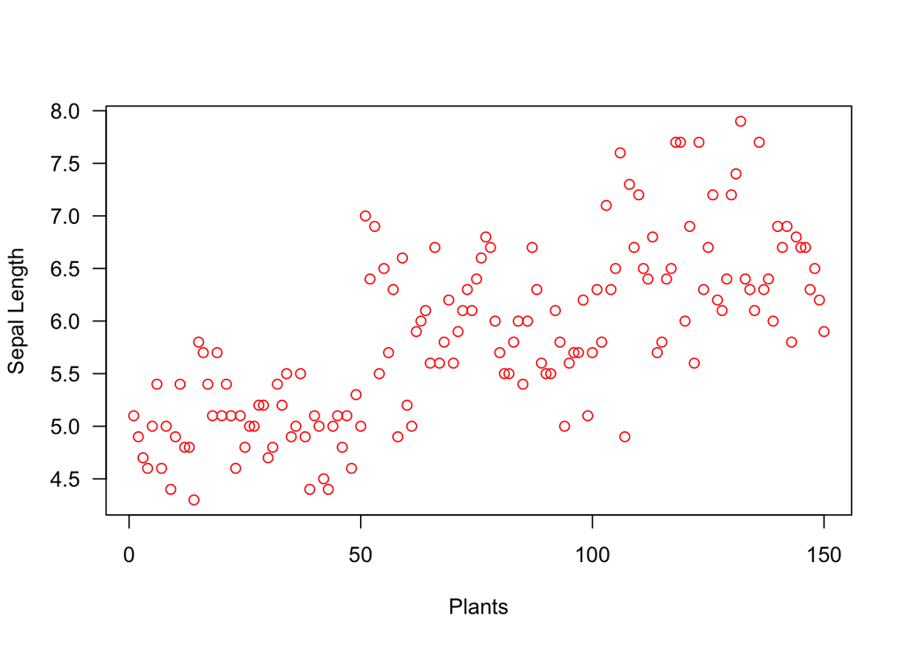

```r
plot(iris$Sepal.Length, col="red",xlab="Plants", ylab="Sepal Length", las=1)
```

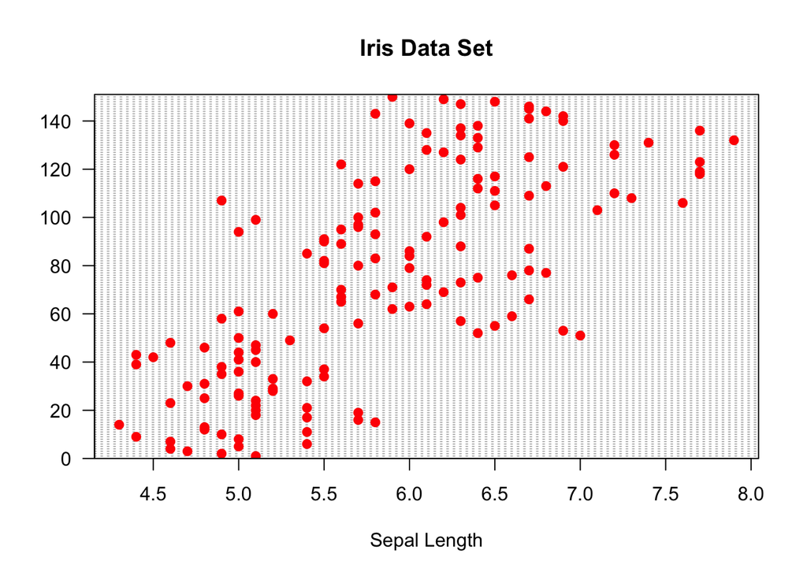

```r
dotchart(iris$Sepal.Length, pch=19, col="red",
         xlab="Sepal Length", main="Iris Data Set")
axis(2, las=1)
```

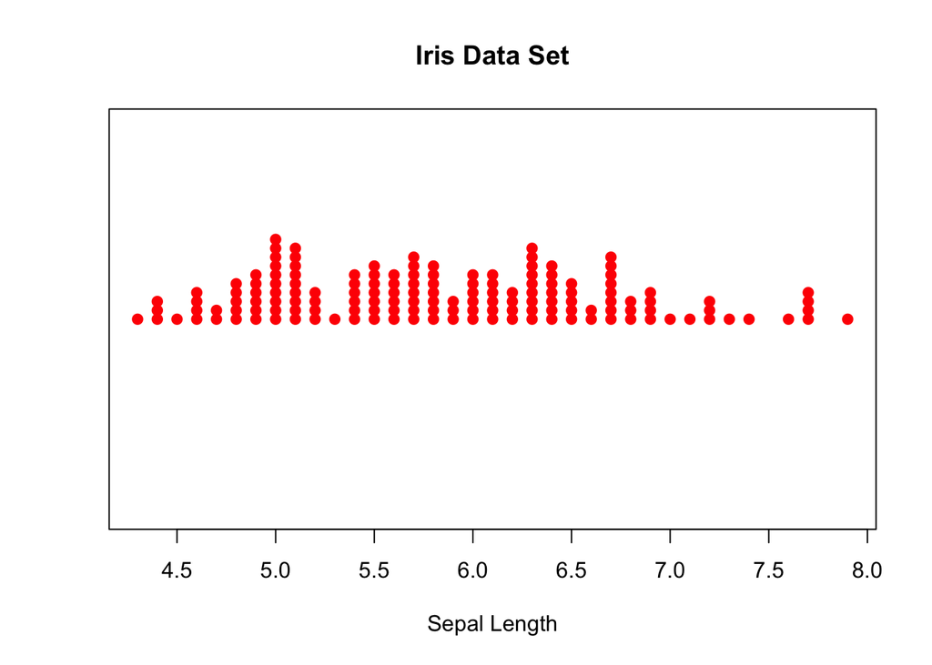

```r
stripchart(iris$Sepal.Length, method="stack", pch=19, col="red",
           xlab="Sepal Length", main="Iris Data Set")
```

```r
stem(iris$Sepal.Length, scale=0.5)
```

```
##
##   The decimal point is at the |
##
##   4 | 3444
##   4 | 566667788888999999
##   5 | 000000000011111111122223444444
##   5 | 5555555666666777777778888888999
##   6 | 00000011111122223333333334444444
##   6 | 5555566777777778889999
##   7 | 0122234
##   7 | 677779
```

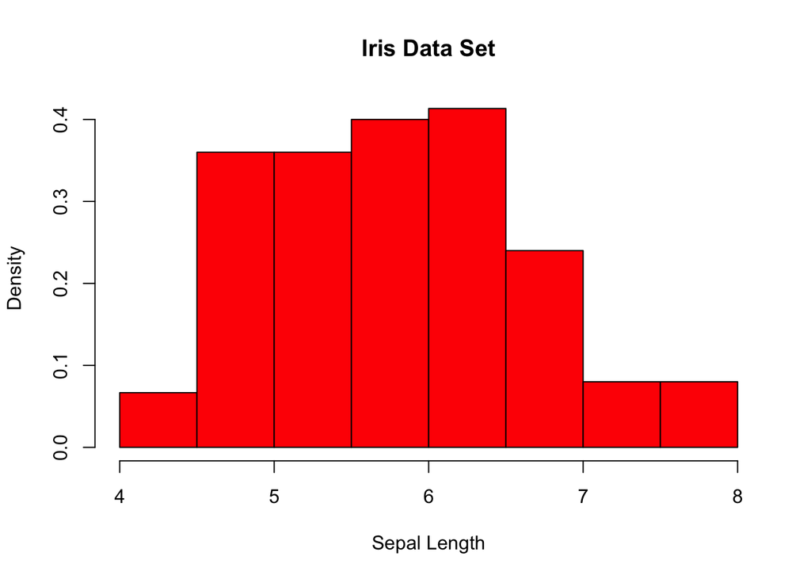

```r
hist(iris$Sepal.Length, freq=FALSE, col="red",
     xlab="Sepal Length", main="Iris Data Set")
```

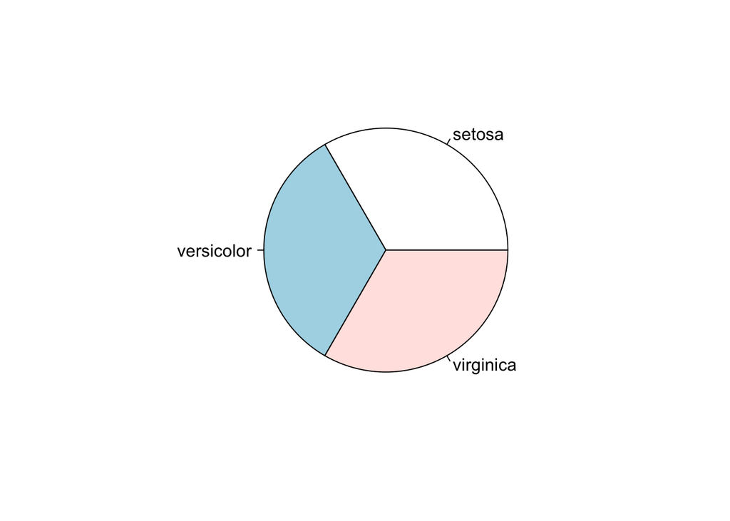

```r
pie(table(iris$Species))
```

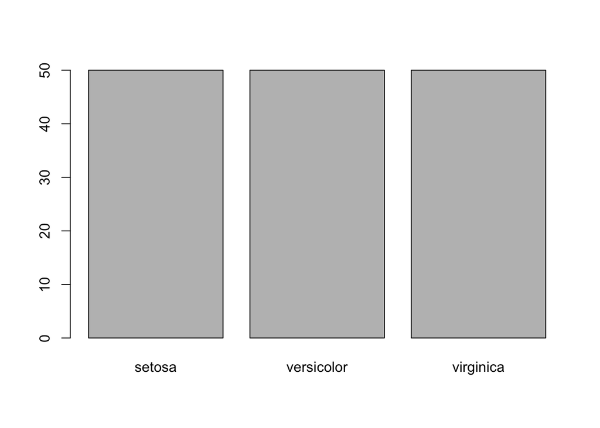

```r
barplot(table(iris$Species))
```

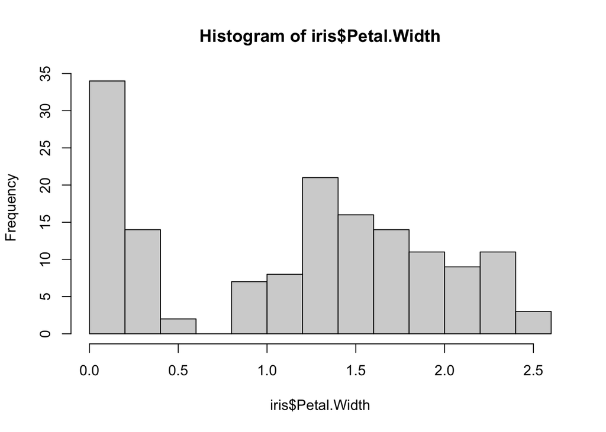

```r
hist(iris$Petal.Width)
```

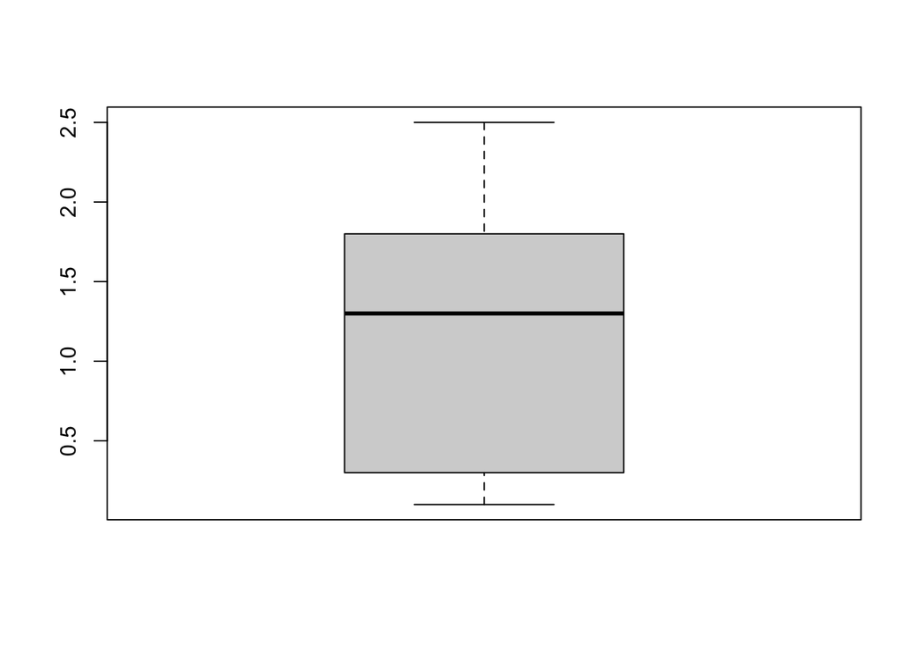

```r
boxplot(iris$Petal.Width)
```

# Exercises

## 1st exercise

We asked 15 friends about what operative system they use. The answers are these (1 = “Linux”, 2 = “MacOX”, 3 = “Windows”):

| $w_{1}$ | $w_{2}$ | $w_{3}$ | $w_{4}$ | $w_{5}$ | $w_{6}$ | $w_{7}$ | $w_{8}$ | $w_{9}$ | $w_{10}$ | $w_{11}$ | $w_{12}$ | $w_{13}$ | $w_{14}$ | $w_{15}$ |
| --- | --- | --- | --- | --- | --- | --- | --- | --- | --- | --- | --- | --- | --- | --- |
| 3 | 3 | 1 | 3 | 2 | 2 | 1 | 3 | 3 | 1 | 1 | 3 | 1 | 2 | 3 |

1. Enter the data. Which type of variable have we?

   ```r
   # Your answer goes here
   ```

2. Which is the size of the sample?

   ```r
   # Your answer goes here
   ```

3. Create the corresponding frequency table (`table()`, `tabulate()`)

   ```r
   # Your answer goes here
   ```

4. Which graph will you choose for plotting these data?

   ```r
   # Your answer goes here
   ```

5. Use the `pie()` function. (Remember, use help). Do you find that something is missing in the graph you plotted? Use help for understanding the `mtext()` function.

   ```r
   # Your answer goes here
   ```

6. Use the function `barplot()`.

   ```r
   # Your answer goes here
   ```

## 2nd exercise

Look this two images:

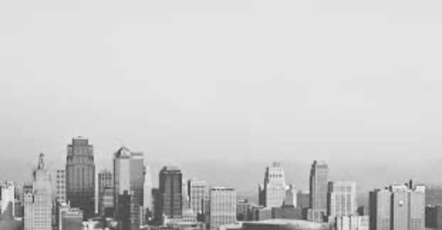

[figure not shown]

image1.jpg

image2.jpg

In the files `"image1.csv"` and “`image2.csv"`, we have the measures of the gray scale of every pixel that make up the images.

1. Read the data with R (`"image1.csv"` and “`image2.csv"`).

   ```r
   # Your answer goes here
   ```

2. Which graph will you plot for displaying the gray scale of each image?

   ```r
   # Your answer goes here
   ```

3. What values do you expect for the first image? And for the other? Did the graphs you have plotted show this?

   ```r
   # Your answer goes here
   ```

## 3rd exercise

In this exercise you will analyze the data about a survey.

1. Which is your current working directory?

   ```r
   # Your answer goes here
   ```

2. Locate yourself in the most convenient directory for you.

   ```r
   # Your answer goes here
   ```

3. Read the data stored in the file *“*`survey.txt"`.

   ```r
   # Your answer goes here
   ```

4. Which are the names of the columns?

   ```r
   # Your answer goes here
   ```

5. How would you choose the second variable? And the responses of the fourth individual?

   ```r
   # Your answer goes here
   ```

6. Use the function `summary()` for variables *genre* and *height*. Comment the results.

   ```r
   # Your answer goes here
   ```

7. Represent the answers of the question *“How do you come to class?”* with a graph.

   ```r
   # Your answer goes here
   ```

8. Represent graphically the answers to the question *“How much time do you spend in the commute from home to the campus?”. Comment what you see. (Take a look to the functions `hist()`,* `stem()` and `stripchart()`.

   ```r
   # Your answer goes here
   ```